# Writing your syllabus

Bernhard Bieri

2022-11-09

`{iheiddown}` is not only a tool for students to write their thesis in. It can also be of use for teaching activities at IHEID as it harbors a great looking template for course syllabi. This short article will walk you through the workflow of writing your very own syllabus in R.

## Installation

The installation process is the same than for the thesis template. You’ll need the following software:

1. Install [R](https://cran.r-project.org) and [R-Studio](https://posit.co/)
2. Install a LATEX distribution:
   - [For MacOS](https://www.tug.org/mactex/)
   - [For Windows](https://miktex.org/)
   - [For Linux](https://www.tug.org/texlive/)
3. Install `{iheiddown}` by typing the following command `install.packages("iheiddown")` in the R-Studio console.

Note: typing `remotes::install_github("jhollway/iheiddown")` will provide you with the latest version from GitHub.

## Create your first syllabus

Creating your first syllabus is easy! Let’s look at how it is done. Before we begin, we have to create a new R project by clicking on the file tab in the top of the RStudio window and following the instructions of the prompt that appears. Now that we have created an R project for our presentation, we can open a new R-Markdown file. To do this click on the “plus file” logo in the top left corner and then on “R-Markdown”.

[figure not shown]

After you have done this, a little pop-up helper will appear. The first thing we will do is to select the `{iheiddown}` template for our presentation. To do so, click on the “From Template” option on the left and select the “Syllabus {iheiddown}” template. Now give your file a name and click on “OK”.

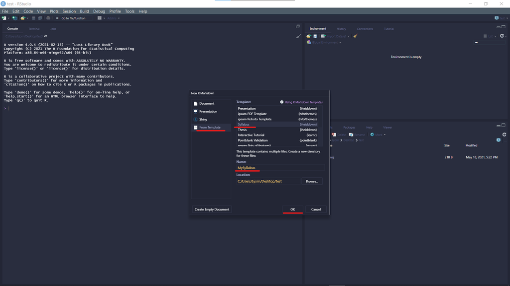

Step 2: Select a template

Congrats! You just created your first syllabus! We can actually already render our syllabus. This is done by simply clicking the “knit button” while viewing the `MySyllabus.Rmd` pane. Et voilà! You have now successfully generated your first syllabus with R.

Take a moment to read through the generated syllabus to get acquainted with the `{R-markdown}` syntax and to get a feel of the possibilities of the `{iheiddown}` theme.

## Edit your syllabus

This section will focus on giving you an overview of the workflow of creating your syllabus with the `{iheiddown}` package.

### Set YAML options

The general options are set in the YAML header. You can define the contact information of the instructor and the teaching assistant as well as give a general course description or set evaluation policies.

You can also set bibliographic options such as the `.bib` file you want to draw your references from (`references.bib` by default) and the style of the bibliographic entries by altering the `.csl` file.

### Setting the start-date of your course

The second step is to set the correct start date of your course in the main `MySyllabus.Rmd` file. This is done simply by editing the `startdate` variable in the first code chunk.

### Editing your course description

The third and last step is to edit the main body of the syllabus. To do this, simply write the title of each week’s session, a description if necessary and add citations of the weeks material with the id of the reference in the bib file preceded by “@” e.g. `@Darwin1958`.